# Homework 4. Random forest

Mike

15 мая 2017 г

```r
library(randomForest)
library(rpart)
library(rattle)
library(rpart.plot)
library(RColorBrewer)
library(dplyr)
library(ggplot2)

set.seed(1408)
```

### Данные

Данные возьмем из статьи “A novel strategy for forensic age prediction by DNA methylation and support vector regression model”, Cheng Xu et al, Scientific reports 2015. Авторы попытались построить предсказатель возраста человека по данным метилирования отдельных CpG sites.

**ages.tsv** – идентификаторы доноров: возраст, и название array, которым это всё добро сделали.

**methylation.tsv** – данные про CpG сайты: где эти сайты на геноме находятся, доля метилирования каждого сайта у наших доноров. Однако в этой табличке также есть NA-значения, авторы статьи утверждают, что это означает “no methylation detected”, и считают их за 0

```r
ages <- read.table("../data/ages.tsv", sep="\t", header=1)
head(ages)
```

```
##   Sample Age              Array
## 1    F78  20 Sequenom Massarray
## 2    F79  21 Sequenom Massarray
## 3    F80  22 Sequenom Massarray
## 4    F81  23 Sequenom Massarray
## 5    F82  24 Sequenom Massarray
## 6    F83  25 Sequenom Massarray
```

```r
methylation <- read.table("../data/methylation.tsv", sep="\t", header=1, row.names = 1, na.strings = "NA")
methylation <- methylation %>% mutate_all(funs(replace(., is.na(.), 0)))
print(methylation[1:5, 1:5])
```

```
##   Primer Chr                   Position  F78  F79
## 1     P1   1                   43425337 0.24 0.09
## 2     P1   1 43425369;43425373;43425375 0.63 0.25
## 3     P1   1                   43425385 0.69 0.44
## 4     P1   1          43425452;43425460 0.88 0.45
## 5     P1   1                   43425479 0.89 0.43
```

### Предподготовка данных

Вообще сайтов метилирования там какое-то не очень большое количество (95 сайтов), однако часть из них абсолютно не скоррелирована с возрастом, и наверняка вряд ли поможет нам в решении задачи регрессии. Хочется проделать примерно то же, что проделали авторы статьи – сделать ручками очень простой feature selection. Оставим только те, сайты метилирования, которые наиболее скоррелированы с возрастом.

Для каждого сайта метилирования, посчитать корреляцию между долей метилирования этого сайта в доноре и возрасте донора. Для начала возьмем 10 сайтов с максимальной корреляцией и 10 с минимальной (отрицательной), хитро отсортируем их так, чтобы по центру были сайты с корреляцией, максимальной по модулю.

```r
top_sites_neg <- apply(methylation, 1, function(x) c(site = x[3], cor_ = cor(as.numeric(x[4:length(x)]), ages$Age))) %>%
  t(.) %>%  data.frame(., stringsAsFactors = F) %>% mutate(cor_ = as.numeric(cor_)) %>%  top_n(., 10, -cor_)

top_sites_pos <- apply(methylation, 1, function(x) c(site = x[3], cor_ = cor(as.numeric(x[4:length(x)]), ages$Age))) %>%
  t(.) %>%  data.frame(., stringsAsFactors = F) %>% mutate(cor_ = as.numeric(cor_)) %>%  top_n(., 10, cor_)


top_sites <- rbind(arrange(top_sites_neg, desc(cor_)), arrange(top_sites_pos, desc(cor_)))
print(top_sites)
```

```
##                 site.Position       cor_
## 1                     1713240 -0.5244943
## 2                   154582196 -0.5337937
## 3                    77299956 -0.5406696
## 4                    77299980 -0.5708317
## 5             1713005;1713007 -0.5711231
## 6           42467726;42467728 -0.5714037
## 7                   154582288 -0.5807119
## 8                   154582007 -0.5844556
## 9                   154582187 -0.5912313
## 10                   42467780 -0.5978078
## 11 18343937;18343941;18343943  0.4412766
## 12                   18343915  0.4311030
## 13                   18343880  0.4099792
## 14                   18343868  0.3422604
## 15            1823523;1823529  0.3062946
## 16                   33085736  0.2731339
## 17                   18343852  0.2553760
## 18                   18344003  0.2536856
## 19                   76557030  0.2400806
## 20            1823556;1823560  0.2204320
```

```r
# Предикторы
data <-
  rbind(filter(methylation, Position %in% top_sites_neg$site.Position) %>% arrange(desc(top_sites_neg$cor_)),
        filter(methylation, Position %in% top_sites_pos$site.Position) %>% arrange(desc(top_sites_pos$cor_))) %>%
    select(-c(1:3)) %>% t() %>%
    data.frame()

# Вектор ответов - возраст
response <- ages$Age
```

### Рабочая функция

Для анализа нам нужна будет функция-обертка, которая все сделает за нас: она принимает на вход data и response, в цикле по runs.number проводит кросс-валидацию для разных разбиений на тренировочную и тестовую выборки в соотношении 80/20, возвращает среднее по всем прогонам для тренировочной и тестовой выборок.

```r
#' randomForest wrapper and error estimator
#'
#' @param data data.frame, dataset
#' @param response numeric vector, values of dependent variables in dataset
#' @param runs.number numeric (integer), how many times we should run random forest
#' @param ... parameters that are passes to randomForest function, like
#'        ntree, mtry, nodesize, replace, sampsize
#'
#' @return numeric vector with two values,
#'      first is mean of RMSE values on training data
#'      second is mean of RMSE values on testing data
#' @export
#'
#' @examples
wrapper <- function(data, response,
                    runs.number=20, ...) {


  rmse <- sapply(seq(runs.number), function(x) {

    # Здесь будет кросс-валидация сразу, потому что иначе потом мы уткнемся в переобучение на конкретное разбиение
    # Для усреднения будем брать 20 (по умолчанию) различных разбиений на тестовую и валидирующую,
    # соответственно, суммарно 100 запусков при соотношении 80:20
    cross.validation <- matrix(sample(1:50, 50), nrow=5, ncol=10)

    cross.results <- apply(cross.validation, 1, function(test.sample){
      # using each part as testing dataset
      # using rest of the dataset as training dataset
      train.sample <- (1:50)[-test.sample]
      train.data <- data[train.sample, ]
      train.response <- response[train.sample]
      test.data <- data[test.sample, ]
      test.response <- response[test.sample]

      # calculating RMSE for every part and default random forest
      fit.rf <- randomForest(x = train.data, y = train.response, runs.number=runs.number, ...)
      prediction_test <- predict(fit.rf, test.data)
      prediction_train <- predict(fit.rf, train.data)
      rmse_test <- sqrt(sum((prediction_test - test.response)^2)/length(prediction_test))
      rmse_train <- sqrt(sum((prediction_train - train.response)^2)/length(prediction_train))

      return(c(rmse_train, rmse_test))

    })

    return(rowMeans(cross.results))

  })

  return(c(rmse.train = mean(rmse[1, ]), rmse.test = mean(rmse[2, ])))
}
```

Посмотрим, что получилось: запустим классификатор по умолчанию и с одним деревом (так себе вариант)

```r
# Test: запуск randomForest с аргументами по умолчанию 20 раз и подсчет средней ошибки
errors.defaults <- wrapper(data, response, 20)
print(errors.defaults)
```

```
## rmse.train  rmse.test
##   4.223936   9.831750
```

```r
# Test: запуск randomForest всего с 1 деревом внутри 20 раз и подсчет средней ошики
errors.ntree1 <- wrapper(data, response, 20, ntree=1)
print(errors.ntree1)
```

```
## rmse.train  rmse.test
##    9.41186   14.45161
```

[figure not shown]

Результат ожидаемый: на одном дереве далеко не уедешь.

### Feature selection

Ранее мы отобрали 20 сайтов метилирования: 10 с положительной и 10 с отрицательной корреляцией. Теперь попробуем выяснить, какие сайты помогут лучше предсказать возраст и сколько их нужно (придется подождать). Для этого построим все возможные комбинации начал и концов массива фичей, посмотрим на ошибку для каждого набора.

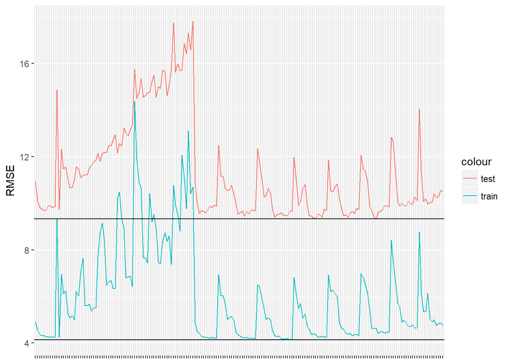

```r
s_e <- combn(1:20, 2)
s_e_error <- apply(s_e, 2, function(x) wrapper(data[, c(x[1]:x[2])], response))

border_error <- data.frame(borders = apply(s_e, 2, function(x) paste(x, collapse = "-")), t(s_e_error))
border_error <- border_error[order(border_error$rmse.test), ]

ggplot(border_error, aes(x = borders, group = 1))+
  geom_line(aes(y = rmse.train, col = "train"))+
  geom_hline(yintercept = min(border_error$rmse.train))+
  geom_line(aes(y = rmse.test, col = "test"))+
  geom_hline(yintercept = min(border_error$rmse.test))+

  ylab("RMSE")+
  theme(axis.text.x = element_blank(), axis.title.x=element_blank())
```

```r
head(border_error)
```

```
##     borders rmse.train rmse.test
## 106    7-14   4.649159  9.335069
## 80     5-15   4.359286  9.347067
## 79     5-14   4.390477  9.385139
## 94     6-15   4.388292  9.396613
## 83     5-18   4.298829  9.400313
## 62     4-12   4.320897  9.408197
```

```r
# Cохраним данные исходной статьи, чтобы посмотреть, насколько в итоге выйдет лучше
original_data <- data[, c(1:10)]
# Кажется, что диапазон 7-14 нам подходит, будем работать с ними
data <- data[, c(7:14)]
```

##### PCA

Посмотрим, насколько мы правы. Ожидаем, что мы выбрали необходимый и достаточный набор слабо скоррелированных предикторов

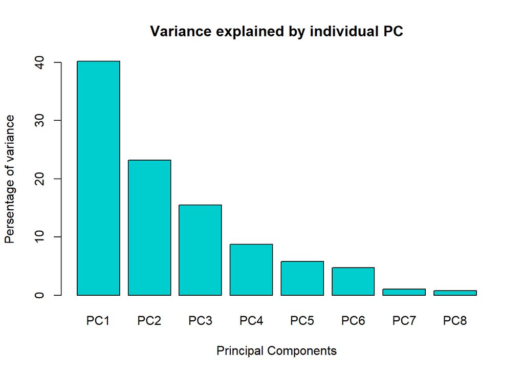

```r
pc <- prcomp(data, scale = T, center = T)
barplot(summary(pc)$importance[2,]*100, ylab = "Persentage of variance", xlab = "Principal Components", main = "Variance explained by individual PC", col = "cyan3")
```

```r
sum(summary(pc)$importance[2,1:4]*100)
```

```
## [1] 87.721
```

Вроде так и получилось: распределение вклада компонент позволяет предположить, что все верно.

### Оптимизация обучения

Таким образом, если бы мы хотели, чтобы в нашем лесу, все деревья были переобучены, мы бы запустили это как-нибудь в духе:

```r
# запуск randomForest со всеми вершинами (nodesize=1), replace=F, sampsize=N, mtry=M
errors.overfit <- wrapper(data, response,
                          nodesize=1, replace=F, sampsize=40, mtry=8, ntree=100)
print(errors.overfit)
```

```
## rmse.train  rmse.test
##    0.00000   12.96316
```

Далее по очереди подберем все параметры, фиксируя остальные.

##### Количество деревьев (ntree)

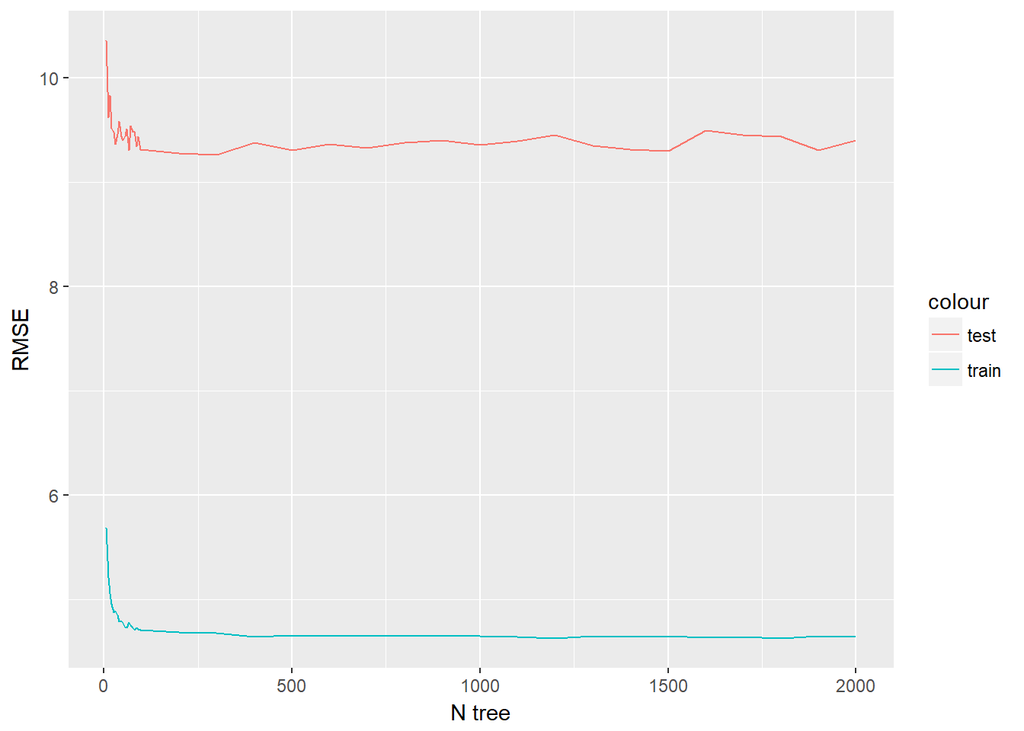

```r
n <- c(seq(1, 100, 5), seq(200, 2000, 100))
rmse.ntree <- sapply(n, function(x) wrapper(data, response, ntree=x))

ggplot(data.frame(n[-c(1)], t(rmse.ntree)[-c(1),]), aes(x = n[-c(1)]))+
  geom_line(aes(y = rmse.train, col = "train"))+
  geom_line(aes(y = rmse.test, col = "test"))+
  ylab("RMSE")+
  xlab("N tree")
```

```r
# Во имя скорости возьмем 200 деревьев, потому что разницы почти нет
wrapper(data, response, ntree=200)
```

```
## rmse.train  rmse.test
##   4.675119   9.292699
```

##### Размер выборки (sampsize) и перестановки (replace)

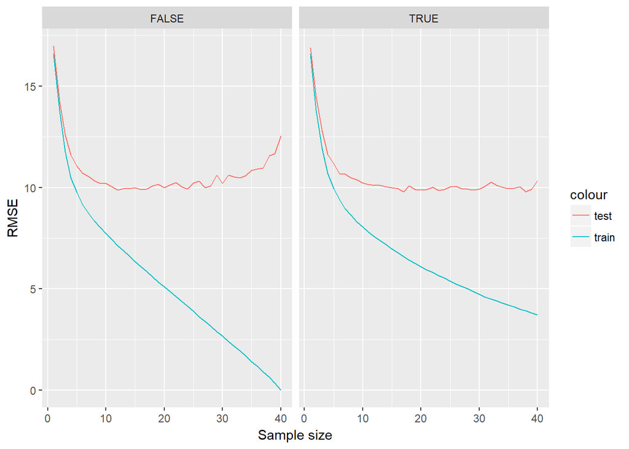

```r
ss <- c(1:40)

rmse.sampsize_repT <- sapply(ss, function(x) wrapper(data, response, ntree = 200, mtry = 8, nodesize = 1, replace = T, sampsize=x))

rmse.sampsize_repF <- sapply(ss, function(x) wrapper(data, response, ntree = 200, mtry = 8, nodesize = 1, replace = F, sampsize=x))

to_plot <- rbind(data.frame(ss, data.frame(rep = F, t(rmse.sampsize_repF))), data.frame(ss, data.frame(rep = T, t(rmse.sampsize_repT))))

ggplot(data.frame(ss, to_plot), aes(x = ss))+
  facet_grid(. ~ rep)+
  geom_line(aes(y = rmse.train, col = "train"))+
  geom_line(aes(y = rmse.test, col = "test"))+
  ylab("RMSE")+
  xlab("Sample size")
```

```r
# Optimal
wrapper(data, response, ntree = 200, replace = T, sampsize = 30)
```

```
## rmse.train  rmse.test
##   5.675374   9.470937
```

Overfitting detected (см. левый график)! Используем `replace = T, sampsize = 30`

##### Минимальный размер для листовых вершин (nodesize)

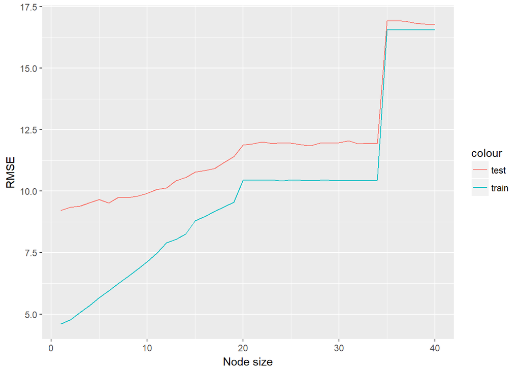

```r
nodes <- c(1:40)
rmse.nodesize <- sapply(nodes, function(x) wrapper(data, response, ntree = 200, replace = T, sampsize = 30,  nodesize=x))

ggplot(data.frame(nodes, t(rmse.nodesize)), aes(x = nodes))+
  geom_line(aes(y = rmse.train, col = "train"))+
  geom_line(aes(y = rmse.test, col = "test"))+
  ylab("RMSE")+
  xlab("Node size")
```

```r
# Optimal
wrapper(data, response, ntree = 200, replace = T, sampsize = 30,  nodesize=1)
```

```
## rmse.train  rmse.test
##   4.559378   9.314517
```

##### Количество признаков при случайном разбиении - feature bagging (mtry)

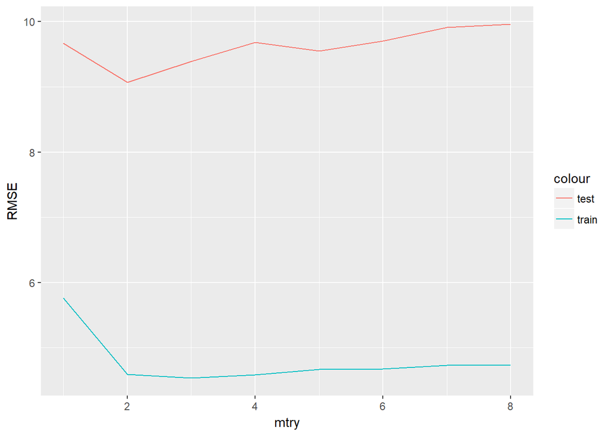

```r
m <- c(1:8)
rmse.mtry <- sapply(m, function(x) wrapper(data, response, ntree = 200, replace = T, sampsize = 30,  nodesize=1,  mtry=x))

ggplot(data.frame(m, t(rmse.mtry)), aes(x = m))+
  geom_line(aes(y = rmse.train, col = "train"))+
  geom_line(aes(y = rmse.test, col = "test"))+
  ylab("RMSE")+
  xlab("mtry")
```

```r
# Optimal
wrapper(data, response, ntree = 200, replace = T, sampsize = 30,  nodesize=1,  mtry=2)
```

```
## rmse.train  rmse.test
##   4.592874   9.303300
```

##### Проверка

Посмотрим, что мы настроили на большом числе runs.number

```r
# Optimal
wrapper(data, response, ntree = 200, replace = T, runs.number = 100, sampsize = 30,  nodesize=1,  mtry=2)
```

```
## rmse.train  rmse.test
##   4.594594   9.254644
```

```r
# Non-optimal (???)
wrapper(data, response, runs.number = 100)
```

```
## rmse.train  rmse.test
##   4.651833   9.400889
```

```r
# Original data
wrapper(original_data, response, runs.number = 100)
```

```
## rmse.train  rmse.test
##    4.90933   10.79925
```

### Выводы

Тюнинг себя почти не оправдал, можно использовать randomForest с настройками по умолчанию и не париться. Feature selection себя оправдал, используем в качестве фичей сайты:

```
##                 site.Position       cor_
## 7                   154582288 -0.5807119
## 8                   154582007 -0.5844556
## 9                   154582187 -0.5912313
## 10                   42467780 -0.5978078
## 11 18343937;18343941;18343943  0.4412766
## 12                   18343915  0.4311030
## 13                   18343880  0.4099792
## 14                   18343868  0.3422604
```